# Tugas Kelompok MPDW Pertemuan 10

G1401211001 Karimatu Ain  
G1401211022 Much.Fazrin Sepranjani Fatah  
G1401211073 Kamilah Nurul Azizah  
G1401211087 Pingkan Febbe Fiorela Kereh  
G1401211106 Megawati Roito Panjaitan

## Packages dan Data

### Library

```r
library(ggplot2)
library(tsibble)
library(tseries)
library(MASS)
library(dplyr)
library(TTR)
library(forecast)
library(lmtest)
library(orcutt)
library(HoRM)
library(dLagM)
library(dynlm)
library(MLmetrics)
library(car)
library(TSA)
library(aTSA)
library(rugarch)
```

### Import Data

Data yang digunakan merupakan data harga bawang merah (rupiah/kg) di kota Surabaya perminggu (Januari 2018 - Agustus 2023) yang bersumber dari bi.go.id

```r
library(rio)
data <- import("https://raw.githubusercontent.com/kamilahnrl/mpdw/main/Kelompok%203/data.xlsx")
str(data)
```

```
## 'data.frame':    295 obs. of  2 variables:
##  $ No         : num  1 2 3 4 5 6 7 8 9 10 ...
##  $ BawangMerah: num  19300 18300 18000 18350 18500 ...
```

## Eksplorasi Data

### Plot Data Penuh

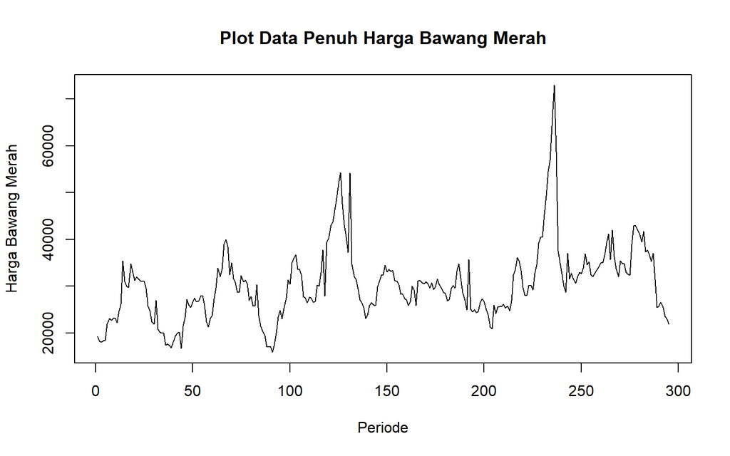

```r
data.ts <- ts(data$BawangMerah)
plot.ts(data.ts, lty=1, xlab="Periode", ylab="Harga Bawang Merah", main="Plot Data Penuh Harga Bawang Merah")
```

Plot deret waktu di atas menunjukkan bahwa data stasioner dalam rataan, ditandai dengan data cenderung menyebar di sekitar nilai tengahnya

### Plot Data Latih

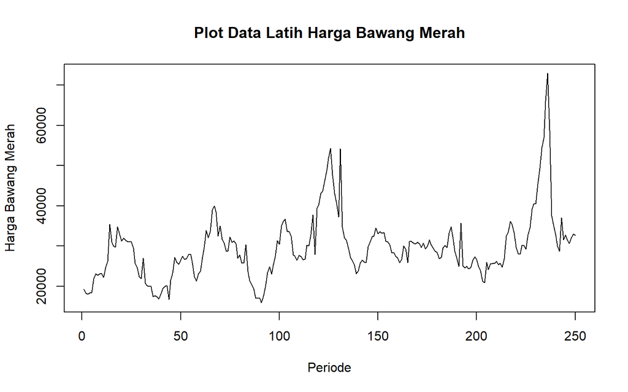

```r
train <- data$BawangMerah[1:250]
train.ts <- ts(train)
plot.ts(train.ts, lty=1, xlab="Periode", ylab="Harga Bawang Merah", main="Plot Data Latih Harga Bawang Merah")
```

Berdasarkan plot data deret waktu pada data latih, terlihat bahwa data stasioner dalam rataan, ditandai dengan data cenderung menyebar di sekitar nilai tengahnya

#### Plot Data Uji

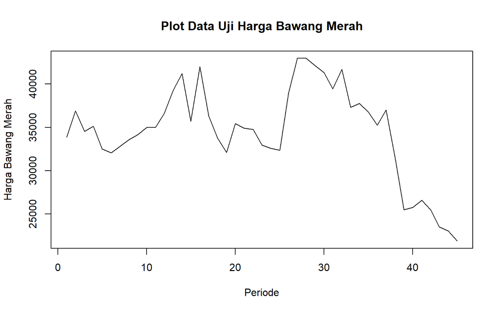

```r
test <- data$BawangMerah[-c(1:250)]
test.ts<-ts(test)
plot.ts(test.ts, lty=1, xlab="Periode", ylab="Harga Bawang Merah", main="Plot Data Uji Harga Bawang Merah")
```

## Uji Stasioneritas Data

### Plot ACF

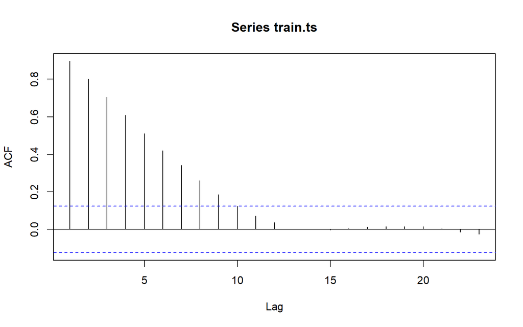

```r
acf(train.ts)
```

Berdasarkan plot ACF, terlihat bahwa plot ACF pada data tersebut *tails off slowly* atau menurun secara perlahan.

### Uji ADF

```r
tseries::adf.test(train.ts)
```

```
##
##  Augmented Dickey-Fuller Test
##
## data:  train.ts
## Dickey-Fuller = -4.1727, Lag order = 6, p-value = 0.01
## alternative hypothesis: stationary
```

$H_0$ : Data tidak stasioner dalam rataan

$H_1$ : Data stasioner dalam rataan

Berdasarkan uji ADF tersebut, didapat *p-value* sebesar 0.01 yang lebih kecil dari taraf nyata 5% sehingga tolak $H_0$ dan menandakan bahwa data stasioner dalam rataan.

### Plot Box-Cox

```r
index <- seq(1:250)
bc = boxcox(train.ts~index, lambda = seq(-2,4,by=0.01))
```

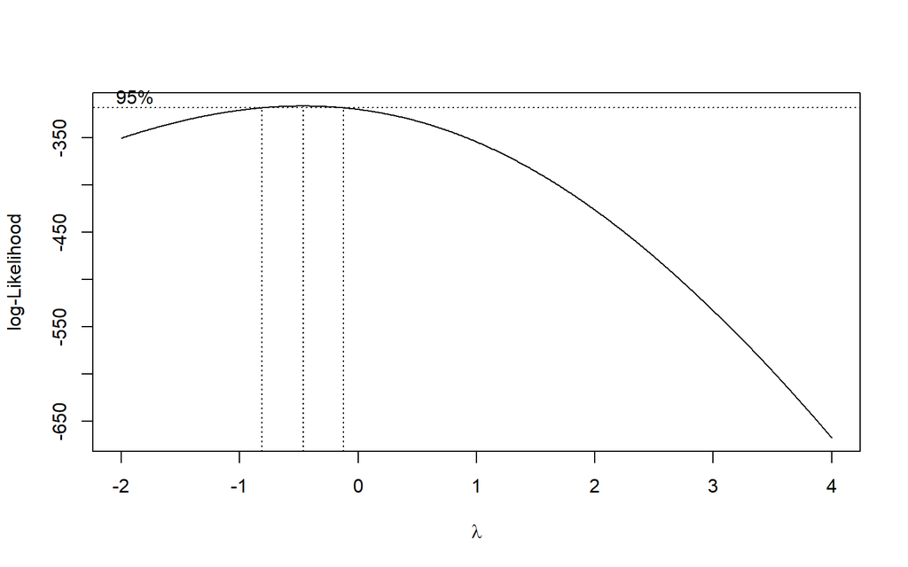

```r
#Nilai Rounded Lambda
lambda <- bc$x[which.max(bc$y)]
lambda
```

```
## [1] -0.46
```

```r
#SK
bc$x[bc$y > max(bc$y) - 1/2 * qchisq(.95,1)]
```

```
##  [1] -0.81 -0.80 -0.79 -0.78 -0.77 -0.76 -0.75 -0.74 -0.73 -0.72 -0.71 -0.70
## [13] -0.69 -0.68 -0.67 -0.66 -0.65 -0.64 -0.63 -0.62 -0.61 -0.60 -0.59 -0.58
## [25] -0.57 -0.56 -0.55 -0.54 -0.53 -0.52 -0.51 -0.50 -0.49 -0.48 -0.47 -0.46
## [37] -0.45 -0.44 -0.43 -0.42 -0.41 -0.40 -0.39 -0.38 -0.37 -0.36 -0.35 -0.34
## [49] -0.33 -0.32 -0.31 -0.30 -0.29 -0.28 -0.27 -0.26 -0.25 -0.24 -0.23 -0.22
## [61] -0.21 -0.20 -0.19 -0.18 -0.17 -0.16 -0.15 -0.14 -0.13
```

Gambar di atas menunjukkan nilai *rounded value* ($\lambda$) optimum sebesar **= -0.46** dan pada selang kepercayaan 95% nilai memiliki batas bawah **-0.81* dan batas atas** -0.13**. Selang tersebut tidak memuat nilai 1 sehingga dapat dikatakan bahwa data tidak stasioner dalam ragam.

Dengan demikian, data stasioner dalam rataan tetapi tidak stasioner dalam ragam.

## Identifikasi Model

### Plot ACF

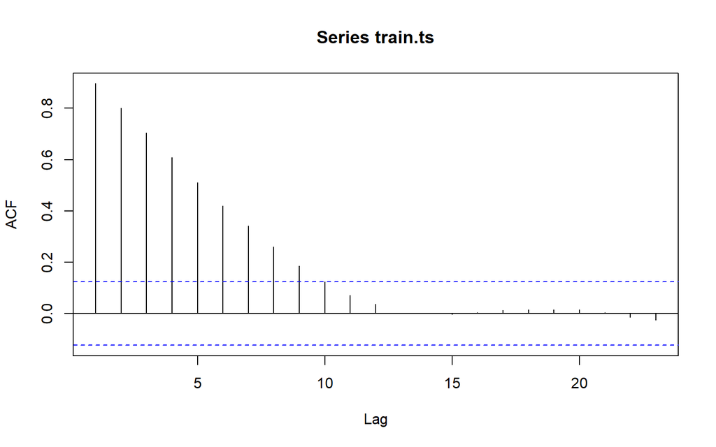

```r
acf(train.ts)
```

Berdasarkan plot tersebut, terlihat bahwa plot ACF *tails off*.

### Plot PACF

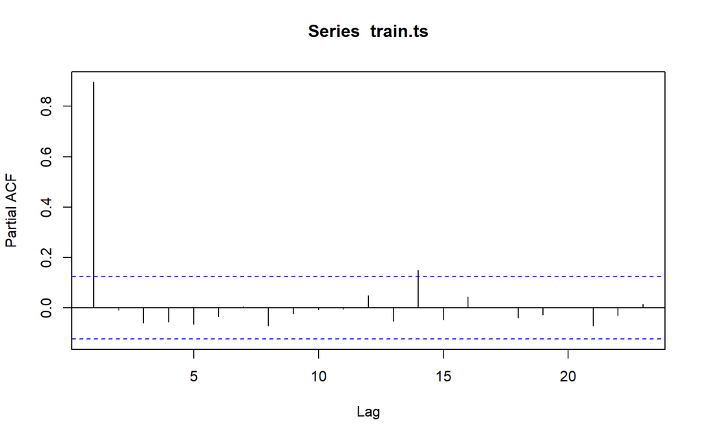

```r
pacf(train.ts)
```

Berdasarkan plot tersebut, terlihat bahwa plot PACF cenderung *cuts off* pada lag ke 1 dan plot ACF menunjukkan *tails off*, maka model tentatifnya adalah ARIMA(1,0,0) atau AR(1).

### Plot EACF

```r
eacf(train.ts)
```

```
## AR/MA
##   0 1 2 3 4 5 6 7 8 9 10 11 12 13
## 0 x x x x x x x x x o o  o  o  o
## 1 o o o o o o o o o o o  o  o  o
## 2 o o o o o o o o o o o  o  o  o
## 3 x o o o o o o o o o o  o  o  o
## 4 x x x o o o o o o o o  o  o  o
## 5 x x x o o o o o o o o  o  o  o
## 6 o x x x o o o o o o o  o  o  o
## 7 o x x x o x o o o o o  o  o  o
```

Identifikasi model menggunakan plot EACF dilakukan dengan melihat ujung segitiga pada pola segitiga nol. Dalam hal ini model tentatif yang terbentuk adalah ARIMA(1,0,0) dan ARIMA (2,0,0)

## Pendugaan Parameter Model Tentatif

### ARIMA(1,0,0)

```r
model1=Arima(train.ts, order=c(1,0,0),method="ML")
summary(model1) #AIC = 4803.98
```

```
## Series: train.ts
## ARIMA(1,0,0) with non-zero mean
##
## Coefficients:
##          ar1       mean
##       0.8991  29446.480
## s.e.  0.0272   2148.626
##
## sigma^2 = 12679296:  log likelihood = -2398.99
## AIC=4803.98   AICc=4804.08   BIC=4814.55
##
## Training set error measures:
##                    ME     RMSE      MAE        MPE     MAPE     MASE
## Training set 59.27675 3546.528 2260.691 -0.9430064 7.326402 1.015445
##                     ACF1
## Training set 0.002600081
```

```r
lmtest::coeftest(model1) #seluruh parameter signifikan
```

```
##
## z test of coefficients:
##
##             Estimate Std. Error z value  Pr(>|z|)
## ar1       8.9909e-01 2.7167e-02  33.095 < 2.2e-16 ***
## intercept 2.9446e+04 2.1486e+03  13.705 < 2.2e-16 ***
## ---
## Signif. codes:  0 '***' 0.001 '**' 0.01 '*' 0.05 '.' 0.1 ' ' 1
```

### ARIMA(2,0,0)

```r
model2=Arima(train.ts, order=c(2,0,0),method="ML")
summary(model2) #AIC = 4805.98
```

```
## Series: train.ts
## ARIMA(2,0,0) with non-zero mean
##
## Coefficients:
##          ar1      ar2       mean
##       0.9025  -0.0037  29445.698
## s.e.  0.0630   0.0633   2144.243
##
## sigma^2 = 12730399:  log likelihood = -2398.99
## AIC=4805.98   AICc=4806.14   BIC=4820.07
##
## Training set error measures:
##                    ME     RMSE      MAE        MPE     MAPE     MASE
## Training set 59.24011 3546.496 2258.657 -0.9428676 7.320043 1.014531
##                      ACF1
## Training set -0.001007811
```

```r
lmtest::coeftest(model2) #ar2 tidak signifikan
```

```
##
## z test of coefficients:
##
##              Estimate  Std. Error z value Pr(>|z|)
## ar1        9.0250e-01  6.3015e-02 14.3220   <2e-16 ***
## ar2       -3.6515e-03  6.3264e-02 -0.0577    0.954
## intercept  2.9446e+04  2.1442e+03 13.7324   <2e-16 ***
## ---
## Signif. codes:  0 '***' 0.001 '**' 0.01 '*' 0.05 '.' 0.1 ' ' 1
```

Berdasarkan pendugaan parameter di atas, nilai AIC terkecil dimiliki oleh model ARIMA(1,0,0) dan seluruh parameternya signifikan sehingga model yang dipilih adalah model ARIMA(1,0,0).

### Overfitting

Tahapan selanjutnya adalah *overfitting* dilakukan dengan menaikkan orde AR(p) dan MA(q) dari model ARIMA(1,0,0) untuk melihat apakah terdapat model lain yang lebih baik dari model saat ini. Kandidat model *overfitting* adalah ARIMA(2,0,0) dan ARIMA(1,0,1).

```r
# ARIMA(2,0,0)
model3=Arima(train.ts, order=c(2,0,0),method="ML")
summary(model3) #AIC = 4805.98
```

```
## Series: train.ts
## ARIMA(2,0,0) with non-zero mean
##
## Coefficients:
##          ar1      ar2       mean
##       0.9025  -0.0037  29445.698
## s.e.  0.0630   0.0633   2144.243
##
## sigma^2 = 12730399:  log likelihood = -2398.99
## AIC=4805.98   AICc=4806.14   BIC=4820.07
##
## Training set error measures:
##                    ME     RMSE      MAE        MPE     MAPE     MASE
## Training set 59.24011 3546.496 2258.657 -0.9428676 7.320043 1.014531
##                      ACF1
## Training set -0.001007811
```

```r
lmtest::coeftest(model3) #ar2 tidak signifikan
```

```
##
## z test of coefficients:
##
##              Estimate  Std. Error z value Pr(>|z|)
## ar1        9.0250e-01  6.3015e-02 14.3220   <2e-16 ***
## ar2       -3.6515e-03  6.3264e-02 -0.0577    0.954
## intercept  2.9446e+04  2.1442e+03 13.7324   <2e-16 ***
## ---
## Signif. codes:  0 '***' 0.001 '**' 0.01 '*' 0.05 '.' 0.1 ' ' 1
```

```r
# ARIMA(1,0,1)
model4=Arima(train.ts, order=c(1,0,1),method="ML")
summary(model4) #AIC = 4805.98
```

```
## Series: train.ts
## ARIMA(1,0,1) with non-zero mean
##
## Coefficients:
##          ar1     ma1       mean
##       0.8986  0.0035  29475.463
## s.e.  0.0301  0.0662   2145.202
##
## sigma^2 = 12730414:  log likelihood = -2398.99
## AIC=4805.98   AICc=4806.14   BIC=4820.07
##
## Training set error measures:
##                    ME     RMSE      MAE        MPE    MAPE     MASE
## Training set 56.20065 3546.498 2259.394 -0.9536075 7.32356 1.014863
##                      ACF1
## Training set -0.000565695
```

```r
lmtest::coeftest(model4) #ma1 tidak signifikan
```

```
##
## z test of coefficients:
##
##             Estimate Std. Error z value Pr(>|z|)
## ar1       8.9857e-01 3.0098e-02 29.8543   <2e-16 ***
## ma1       3.5230e-03 6.6202e-02  0.0532   0.9576
## intercept 2.9475e+04 2.1452e+03 13.7402   <2e-16 ***
## ---
## Signif. codes:  0 '***' 0.001 '**' 0.01 '*' 0.05 '.' 0.1 ' ' 1
```

## Analisis Sisaan

Model terbaik hasil identifikasi kemudian dicek asumsi sisaannya. Sisaan model ARIMA harus memenuhi asumsi normalitas, kebebasan sisaan, dan kehomogenan ragam. Diagnostik model dilakukan secara eksplorasi dan uji formal.

### Eksplorasi

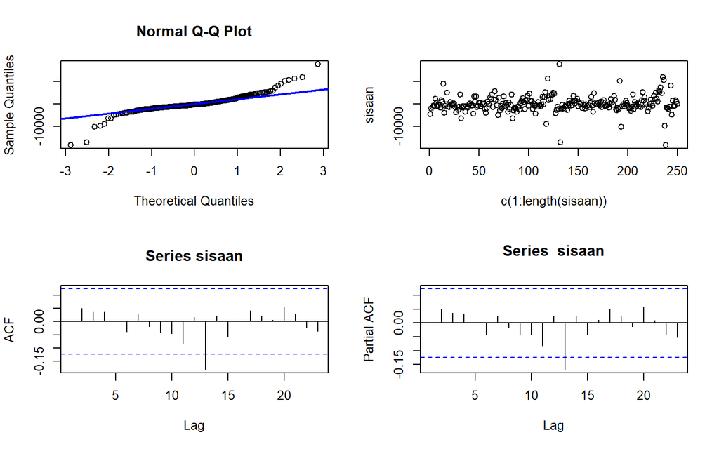

```r
#Eksplorasi
sisaan<- model1$residuals
par(mfrow=c(2,2))
qqnorm(sisaan)
qqline(sisaan, col = "blue", lwd = 2)
plot(c(1:length(sisaan)),sisaan)
acf(sisaan)
pacf(sisaan)
```

```r
par(mfrow = c(1,1))
```

Berdasarkan plot kuantil-kuantil normal, secara eksplorasi ditunjukkan sisaan cenderung menyebar normal mengikuti garis $45^{\circ}$ tetapi beberapa pengamatan di kanan dan kiri tidak mengikuti garis. Kemudian dapat dilihat juga lebar pita sisaan cenderung tidak sama menandakan bahwa sisaan memiliki ragam yang tidak homogen. Plot ACF dan PACF sisaan ARIMA(1,0,0) hanya signifikan pada beberapa lag yang menandakan saling bebas. Kondisi ini akan diuji lebih lanjut dengan uji formal.

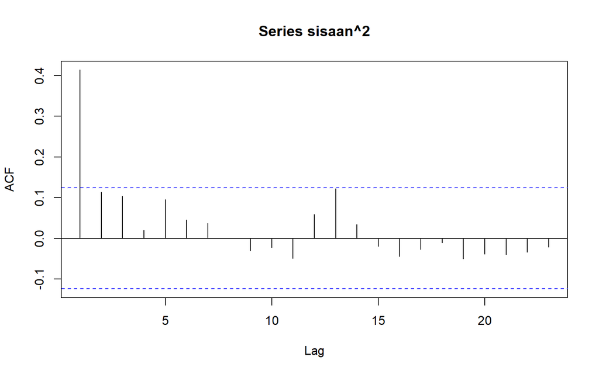

```r
acf(sisaan^2)
```

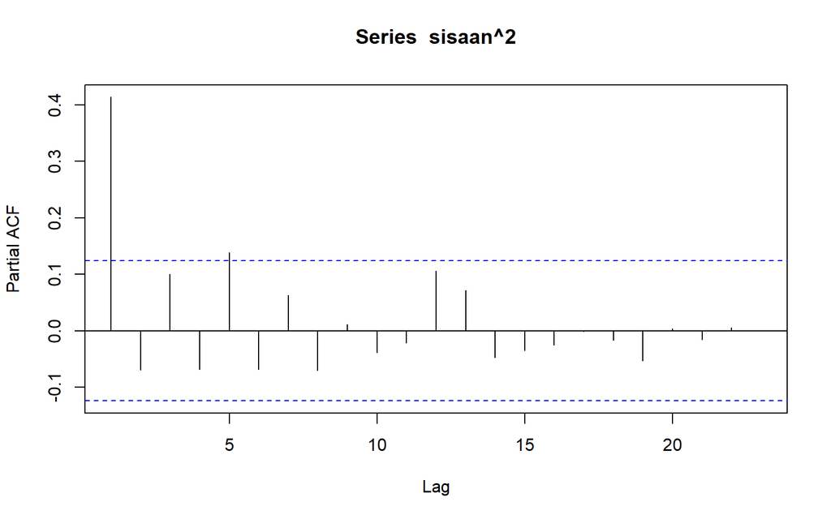

```r
pacf(sisaan^2)
```